# Exploring Credit Risk for Lenders and Borrowers

Jessica Gorr

3/4/2025

## 1. Introduction

The purpose of this analysis is to look at some insights and interesting features of credit card risks for both the lender and borrowers. There have been no methods that describe how or where the the data was collected, so we will not take into account on how countries laws are applicable to lenders. The target variable is loan_status, which describes if a borrower has a defaulted loan. There are two questions we are trying to answer, using linear and logistical regression. The first question is what factors influence the loan amounts? The second question using logistical regression is who will default on their credit (loan_status).

The dataset is composed by 32581 rows (observations) and 12 columns (variables), which are described below:

person_age (numerical): is the age of the person at the time of the loan.

person_income (numerical): is the yearly income of the person at the time of the loan.

person_home_ownership (categorical): is the type of ownership of the home.

person_emp_length (numerical): is the amount of time in years that person is employed.

loan_intent (categorical): is the aim of the loan.

loan_grade (categorical): is a classification system that involves assigning a quality score to a loan based on a borrower’s credit history, quality of the collateral, and the likelihood of repayment of the principal and interest.

loan_amnt (numerical): is the dimension of the loan taken.

loan_int_rate (numerical): is the interest paid for the loan.

loan_status (binary): is a dummy variable where 1 is default, 0 is not default.

loan_percent_income (numerical): is the ratio between the loan taken and the annual income.

cb_person_default_on_file (binary): answers whether the person has defaulted before.

cb_person_cred_hist_length (numerical): represents the number of years of personal history since the first loan taken from that person.

A public link to the data can be found here: https://www.kaggle.com/datasets/laotse/credit-risk-dataset

```r
library(dplyr)
library(reshape2)
library(tidyr)
library(ggplot2)
library(tibble)

#Load the sample data
credit_risk_dataset = read.csv("https://jessgorr01.github.io/STA551/sta552/project1/credit_risk_dataset.csv")


head(credit_risk_dataset)
```

```
  person_age person_income person_home_ownership person_emp_length loan_intent
1         22         59000                  RENT               123    PERSONAL
2         21          9600                   OWN                 5   EDUCATION
3         25          9600              MORTGAGE                 1     MEDICAL
4         23         65500                  RENT                 4     MEDICAL
5         24         54400                  RENT                 8     MEDICAL
6         21          9900                   OWN                 2     VENTURE
  loan_grade loan_amnt loan_int_rate loan_status loan_percent_income
1          D     35000         16.02           1                0.59
2          B      1000         11.14           0                0.10
3          C      5500         12.87           1                0.57
4          C     35000         15.23           1                0.53
5          C     35000         14.27           1                0.55
6          A      2500          7.14           1                0.25
  cb_person_default_on_file cb_person_cred_hist_length
1                         Y                          3
2                         N                          2
3                         N                          3
4                         N                          2
5                         Y                          4
6                         N                          2
```

## 2. Exploratory Data Analysis

### Cleaning and first looks

```r
#Transforming variables to factors
credit_risk_dataset$loan_status <- as.factor(credit_risk_dataset$loan_status)
credit_risk_dataset$person_home_ownership <- as.factor(credit_risk_dataset$person_home_ownership)
credit_risk_dataset$loan_intent <- as.factor(credit_risk_dataset$loan_intent)
credit_risk_dataset$loan_grade <- as.factor(credit_risk_dataset$loan_grade)
credit_risk_dataset$cb_person_default_on_file <- as.factor(credit_risk_dataset$cb_person_default_on_file)

glimpse(credit_risk_dataset) # more ordered
```

```
Rows: 32,581
Columns: 12
$ person_age                 <int> 22, 21, 25, 23, 24, 21, 26, 24, 24, 21, 22,…
$ person_income              <int> 59000, 9600, 9600, 65500, 54400, 9900, 7710…
$ person_home_ownership      <fct> RENT, OWN, MORTGAGE, RENT, RENT, OWN, RENT,…
$ person_emp_length          <dbl> 123, 5, 1, 4, 8, 2, 8, 5, 8, 6, 6, 2, 2, 4,…
$ loan_intent                <fct> PERSONAL, EDUCATION, MEDICAL, MEDICAL, MEDI…
$ loan_grade                 <fct> D, B, C, C, C, A, B, B, A, D, B, A, A, E, A…
$ loan_amnt                  <int> 35000, 1000, 5500, 35000, 35000, 2500, 3500…
$ loan_int_rate              <dbl> 16.02, 11.14, 12.87, 15.23, 14.27, 7.14, 12…
$ loan_status                <fct> 1, 0, 1, 1, 1, 1, 1, 1, 1, 1, 1, 1, 1, 1, 0…
$ loan_percent_income        <dbl> 0.59, 0.10, 0.57, 0.53, 0.55, 0.25, 0.45, 0…
$ cb_person_default_on_file  <fct> Y, N, N, N, Y, N, N, N, N, N, N, N, N, N, N…
$ cb_person_cred_hist_length <int> 3, 2, 3, 2, 4, 2, 3, 4, 2, 3, 4, 2, 2, 4, 4…
```

```r
#str(credit_risk_dataset)
```

The summary of our data, including missing values is below:

```r
summary(credit_risk_dataset)
```

```
   person_age     person_income     person_home_ownership person_emp_length
 Min.   : 20.00   Min.   :   4000   MORTGAGE:13444        Min.   :  0.00
 1st Qu.: 23.00   1st Qu.:  38500   OTHER   :  107        1st Qu.:  2.00
 Median : 26.00   Median :  55000   OWN     : 2584        Median :  4.00
 Mean   : 27.73   Mean   :  66075   RENT    :16446        Mean   :  4.79
 3rd Qu.: 30.00   3rd Qu.:  79200                         3rd Qu.:  7.00
 Max.   :144.00   Max.   :6000000                         Max.   :123.00
                                                          NA's   :895
            loan_intent   loan_grade   loan_amnt     loan_int_rate
 DEBTCONSOLIDATION:5212   A:10777    Min.   :  500   Min.   : 5.42
 EDUCATION        :6453   B:10451    1st Qu.: 5000   1st Qu.: 7.90
 HOMEIMPROVEMENT  :3605   C: 6458    Median : 8000   Median :10.99
 MEDICAL          :6071   D: 3626    Mean   : 9589   Mean   :11.01
 PERSONAL         :5521   E:  964    3rd Qu.:12200   3rd Qu.:13.47
 VENTURE          :5719   F:  241    Max.   :35000   Max.   :23.22
                          G:   64                    NA's   :3116
 loan_status loan_percent_income cb_person_default_on_file
 0:25473     Min.   :0.0000      N:26836
 1: 7108     1st Qu.:0.0900      Y: 5745
             Median :0.1500
             Mean   :0.1702
             3rd Qu.:0.2300
             Max.   :0.8300

 cb_person_cred_hist_length
 Min.   : 2.000
 1st Qu.: 3.000
 Median : 4.000
 Mean   : 5.804
 3rd Qu.: 8.000
 Max.   :30.000
```

```r
colSums(is.na(credit_risk_dataset))  # Number of NAs in each column
```

```
                person_age              person_income
                         0                          0
     person_home_ownership          person_emp_length
                         0                        895
               loan_intent                 loan_grade
                         0                          0
                 loan_amnt              loan_int_rate
                         0                       3116
               loan_status        loan_percent_income
                         0                          0
 cb_person_default_on_file cb_person_cred_hist_length
                         0                          0
```

Some quick insights that can be pulled from the summary of the data are:

1.person_age has a strange result: the max value is 144 which is unlikely to be true. 2.person_emp_length has 895 NAs 3.person_emp_length has a max value of 123 which is not possible. 4.loan_interest_rate has 3116 NAs 5.according to the data (loan_status), 21.82% (7108/32581) of people have defaulted, value that is quite high.

From these insights outliers can be identified. A plot below will focus one two we have potentally found above in our summary.

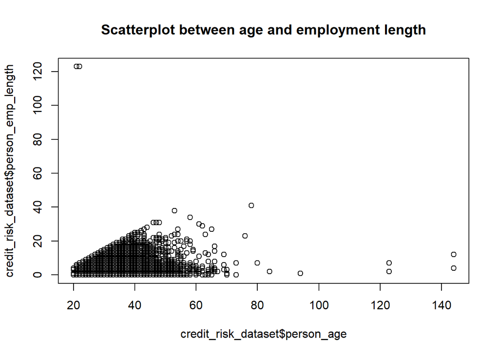

```r
plot(credit_risk_dataset$person_age, credit_risk_dataset$person_emp_length,  main = "Scatterplot between age and employment length")
```

Here it can be clearly seen that there are some issues on data by looking at outliers. It is impossible that two 20 years old have over 120 years of experience. Now illogical outliers must be removed and cleaned from the data before starting exploratory phase. This can be seen below:

```r
credit_risk <- credit_risk_dataset %>%
    filter(!is.na(person_emp_length)) %>%
    filter(!is.na(loan_int_rate)) %>%
    filter(person_age < 90) %>%
    filter(person_emp_length < 100)

summary(credit_risk)
```

```
   person_age    person_income     person_home_ownership person_emp_length
 Min.   :20.00   Min.   :   4000   MORTGAGE:11798        Min.   : 0.00
 1st Qu.:23.00   1st Qu.:  39456   OTHER   :   94        1st Qu.: 2.00
 Median :26.00   Median :  55900   OWN     : 2192        Median : 4.00
 Mean   :27.71   Mean   :  66427   RENT    :14548        Mean   : 4.78
 3rd Qu.:30.00   3rd Qu.:  80000                         3rd Qu.: 7.00
 Max.   :84.00   Max.   :2039784                         Max.   :41.00

            loan_intent   loan_grade   loan_amnt     loan_int_rate
 DEBTCONSOLIDATION:4565   A:9401     Min.   :  500   Min.   : 5.42
 EDUCATION        :5702   B:9149     1st Qu.: 5000   1st Qu.: 7.90
 HOMEIMPROVEMENT  :3198   C:5697     Median : 8000   Median :10.99
 MEDICAL          :5293   D:3247     Mean   : 9655   Mean   :11.04
 PERSONAL         :4875   E: 870     3rd Qu.:12500   3rd Qu.:13.48
 VENTURE          :4999   F: 209     Max.   :35000   Max.   :23.22
                          G:  59
 loan_status loan_percent_income cb_person_default_on_file
 0:22430     Min.   :0.0000      N:23530
 1: 6202     1st Qu.:0.0900      Y: 5102
             Median :0.1500
             Mean   :0.1695
             3rd Qu.:0.2300
             Max.   :0.8300

 cb_person_cred_hist_length
 Min.   : 2.000
 1st Qu.: 3.000
 Median : 4.000
 Mean   : 5.794
 3rd Qu.: 8.000
 Max.   :30.000
```

### Multible Imputation

In order to impute all the missing values in the data, multiple regression imputation will be done through the MICE library. Multiple Regression-based imputation is a method where missing numerical values are predicted using regression models based on other available features. This imputation method helps maintain relationships between variables and provides more accurate imputations compared to mode imputation for categorical variables and median/mean for numerical variables.

Below we will use the mice() library to do a regression based imputation. There are two variable with multiple missing values, person_emp_length, which is how long someone is employed, and loan_int_rate, which is the interest rate of the loan.

```r
# Load necessary package
library(mice)

# Select only numerical columns for regression imputation
num_vars <- c("person_emp_length", "loan_int_rate")

# Perform regression-based imputation
imputed_data <- mice(credit_risk_dataset, method = "norm.predict", m = 1)
# Get the completed dataset with imputed values
credit_risk_dataset_imputed <- complete(imputed_data)

# Check if missing values are removed
colSums(is.na(credit_risk_dataset_imputed))
```

```
                person_age              person_income
                         0                          0
     person_home_ownership          person_emp_length
                         0                          0
               loan_intent                 loan_grade
                         0                          0
                 loan_amnt              loan_int_rate
                         0                          0
               loan_status        loan_percent_income
                         0                          0
 cb_person_default_on_file cb_person_cred_hist_length
                         0                          0
```

```r
summary(credit_risk_dataset)
```

```
   person_age     person_income     person_home_ownership person_emp_length
 Min.   : 20.00   Min.   :   4000   MORTGAGE:13444        Min.   :  0.00
 1st Qu.: 23.00   1st Qu.:  38500   OTHER   :  107        1st Qu.:  2.00
 Median : 26.00   Median :  55000   OWN     : 2584        Median :  4.00
 Mean   : 27.73   Mean   :  66075   RENT    :16446        Mean   :  4.79
 3rd Qu.: 30.00   3rd Qu.:  79200                         3rd Qu.:  7.00
 Max.   :144.00   Max.   :6000000                         Max.   :123.00
                                                          NA's   :895
            loan_intent   loan_grade   loan_amnt     loan_int_rate
 DEBTCONSOLIDATION:5212   A:10777    Min.   :  500   Min.   : 5.42
 EDUCATION        :6453   B:10451    1st Qu.: 5000   1st Qu.: 7.90
 HOMEIMPROVEMENT  :3605   C: 6458    Median : 8000   Median :10.99
 MEDICAL          :6071   D: 3626    Mean   : 9589   Mean   :11.01
 PERSONAL         :5521   E:  964    3rd Qu.:12200   3rd Qu.:13.47
 VENTURE          :5719   F:  241    Max.   :35000   Max.   :23.22
                          G:   64                    NA's   :3116
 loan_status loan_percent_income cb_person_default_on_file
 0:25473     Min.   :0.0000      N:26836
 1: 7108     1st Qu.:0.0900      Y: 5745
             Median :0.1500
             Mean   :0.1702
             3rd Qu.:0.2300
             Max.   :0.8300

 cb_person_cred_hist_length
 Min.   : 2.000
 1st Qu.: 3.000
 Median : 4.000
 Mean   : 5.804
 3rd Qu.: 8.000
 Max.   :30.000
```

```r
summary(credit_risk_dataset_imputed)
```

```
   person_age     person_income     person_home_ownership person_emp_length
 Min.   : 20.00   Min.   :   4000   MORTGAGE:13444        Min.   :  0.000
 1st Qu.: 23.00   1st Qu.:  38500   OTHER   :  107        1st Qu.:  2.000
 Median : 26.00   Median :  55000   OWN     : 2584        Median :  4.000
 Mean   : 27.73   Mean   :  66075   RENT    :16446        Mean   :  4.784
 3rd Qu.: 30.00   3rd Qu.:  79200                         3rd Qu.:  7.000
 Max.   :144.00   Max.   :6000000                         Max.   :123.000

            loan_intent   loan_grade   loan_amnt     loan_int_rate
 DEBTCONSOLIDATION:5212   A:10777    Min.   :  500   Min.   : 5.42
 EDUCATION        :6453   B:10451    1st Qu.: 5000   1st Qu.: 7.88
 HOMEIMPROVEMENT  :3605   C: 6458    Median : 8000   Median :10.99
 MEDICAL          :6071   D: 3626    Mean   : 9589   Mean   :11.01
 PERSONAL         :5521   E:  964    3rd Qu.:12200   3rd Qu.:13.47
 VENTURE          :5719   F:  241    Max.   :35000   Max.   :23.22
                          G:   64
 loan_status loan_percent_income cb_person_default_on_file
 0:25473     Min.   :0.0000      N:26836
 1: 7108     1st Qu.:0.0900      Y: 5745
             Median :0.1500
             Mean   :0.1702
             3rd Qu.:0.2300
             Max.   :0.8300

 cb_person_cred_hist_length
 Min.   : 2.000
 1st Qu.: 3.000
 Median : 4.000
 Mean   : 5.804
 3rd Qu.: 8.000
 Max.   :30.000
```

### Distributions

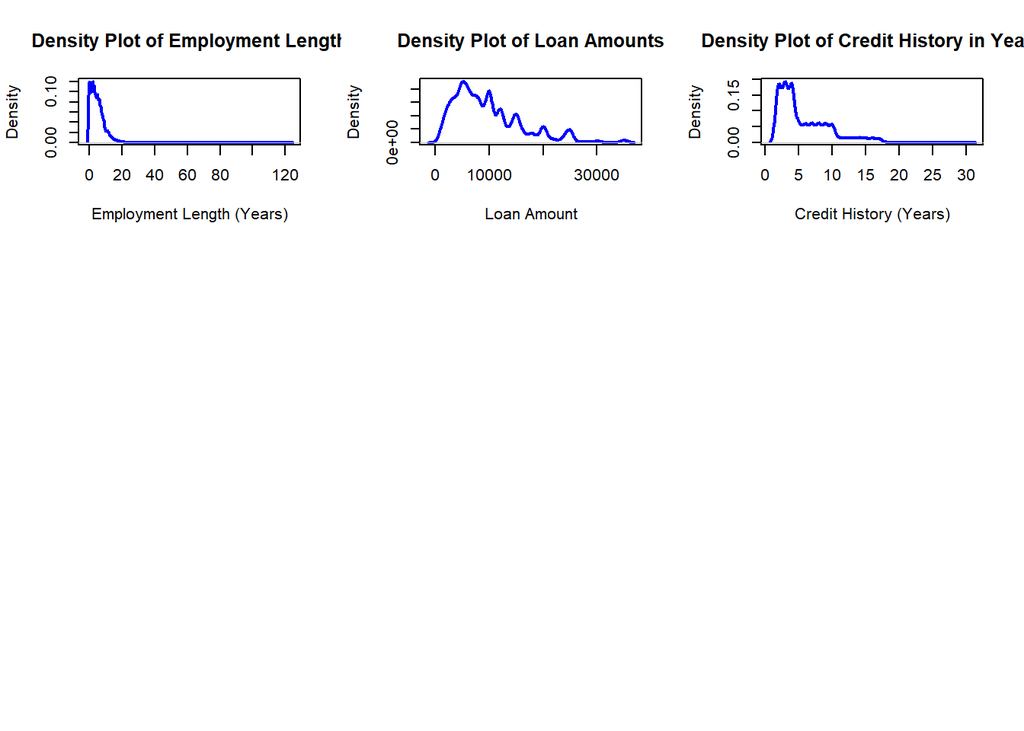

```r
# Set up the panel layout with 3 rows and 3 columns
par(mfrow = c(3, 3))

plot(density(credit_risk_dataset$person_emp_length, na.rm = TRUE), main = "Density Plot of Employment Length",
     xlab = "Employment Length (Years)", ylab = "Density", col = "blue", lwd = 2)

plot(density(credit_risk_dataset$loan_amnt, na.rm = TRUE), main = "Density Plot of Loan Amounts",
     xlab = "Loan Amount", ylab = "Density", col = "blue", lwd = 2)

plot(density(credit_risk_dataset$cb_person_cred_hist_length, na.rm = TRUE), main = "Density Plot of Credit History in Years",
     xlab = "Credit History (Years)", ylab = "Density", col = "blue", lwd = 2)

# Reset plotting layout to default
par(mfrow = c(1, 1))
```

Therefore we can discreteness the credit history into the three groups in order to make the model less complex. Also we can cap the loan amount variable to shorten the data we are looking at in order to hone into the the majority of people. Finally, looking at the employment length, sub-groups can also be made to simplify the model.

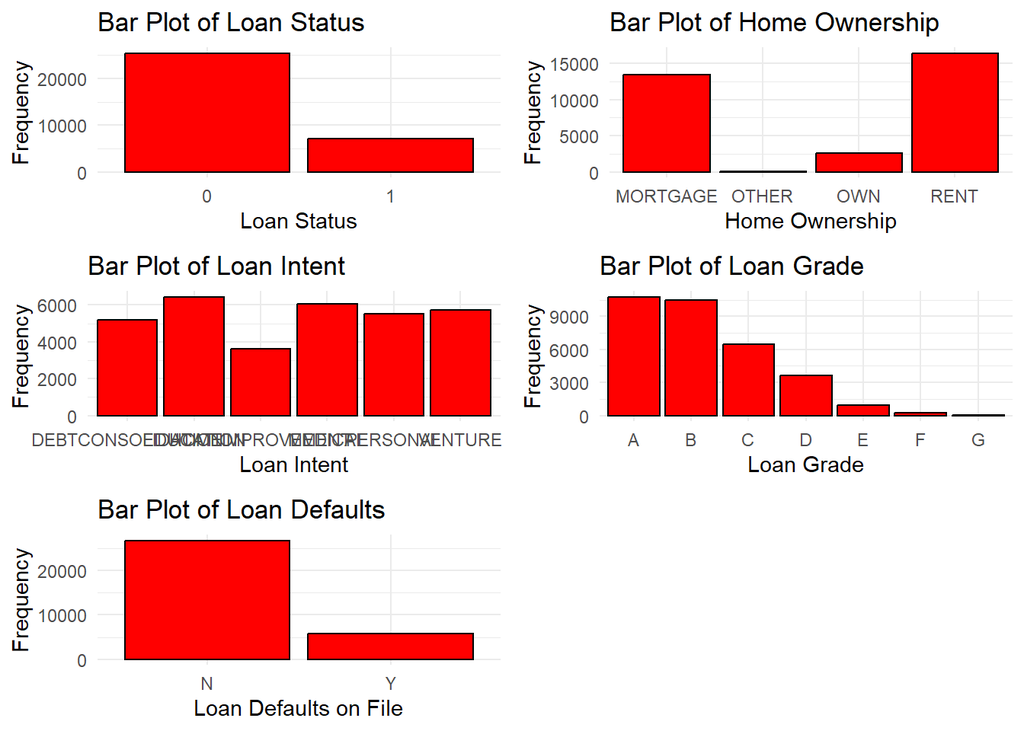

```r
# Load necessary libraries
library(ggplot2)
library(gridExtra)

# Create individual bar plots
p1 <- ggplot(credit_risk_dataset, aes(x = loan_status)) +
  geom_bar(fill = "red", color = "black") +
  ggtitle("Bar Plot of Loan Status") +
  xlab("Loan Status") +
  ylab("Frequency") +
  theme_minimal()

p2 <- ggplot(credit_risk_dataset, aes(x = person_home_ownership)) +
  geom_bar(fill = "red", color = "black") +
  ggtitle("Bar Plot of Home Ownership") +
  xlab("Home Ownership") +
  ylab("Frequency") +
  theme_minimal()

p3 <- ggplot(credit_risk_dataset, aes(x = loan_intent)) +
  geom_bar(fill = "red", color = "black") +
  ggtitle("Bar Plot of Loan Intent") +
  xlab("Loan Intent") +
  ylab("Frequency") +
  theme_minimal()

p4 <- ggplot(credit_risk_dataset, aes(x = loan_grade)) +
  geom_bar(fill = "red", color = "black") +
  ggtitle("Bar Plot of Loan Grade") +
  xlab("Loan Grade") +
  ylab("Frequency") +
  theme_minimal()

p5 <- ggplot(credit_risk_dataset, aes(x = cb_person_default_on_file)) +
  geom_bar(fill = "red", color = "black") +
  ggtitle("Bar Plot of Loan Defaults") +
  xlab("Loan Defaults on File") +
  ylab("Frequency") +
  theme_minimal()

# Arrange plots into a grid layout
grid.arrange(p1, p2, p3, p4, p5, ncol = 2)
```

### Relationship between Features

Now that we have looking the the features individually, we can do some analysis to find insights between the relationships with other features. This insights can provide clarity on what future analysis should focus the attention on. This exploratory analysis will perform three relationship between: 1. two numerical variables 2. two categorical variables 3. one numerical and one categorical variable.

All insights will be explain through visuals and text.

First we will explore the relationship between two numerical variables, age and the loan percentage of their income.

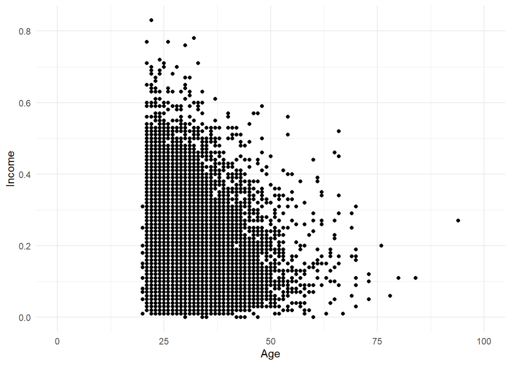

```r
plot1 <- ggplot(credit_risk_dataset, aes(x = person_age, y = loan_percent_income)) +
  geom_point() +
  ylab("Income") +
  xlab("Age") +
  scale_x_continuous(limits = c(0, 100)) +
  theme_minimal()



plot1
```

From this scatterplot, we can clearly see the is a negative correlation between age and loan percentage to income. Younger people tend to have a higher loan percentage of their income compared to older people. This indicates a relationship, and will be explored in a linear regression model later on in this report.

Now looking at two categorical variables we can analyze them visually through a stacked bar plot. Here we will look at the relationship between loan intent and loan grade.

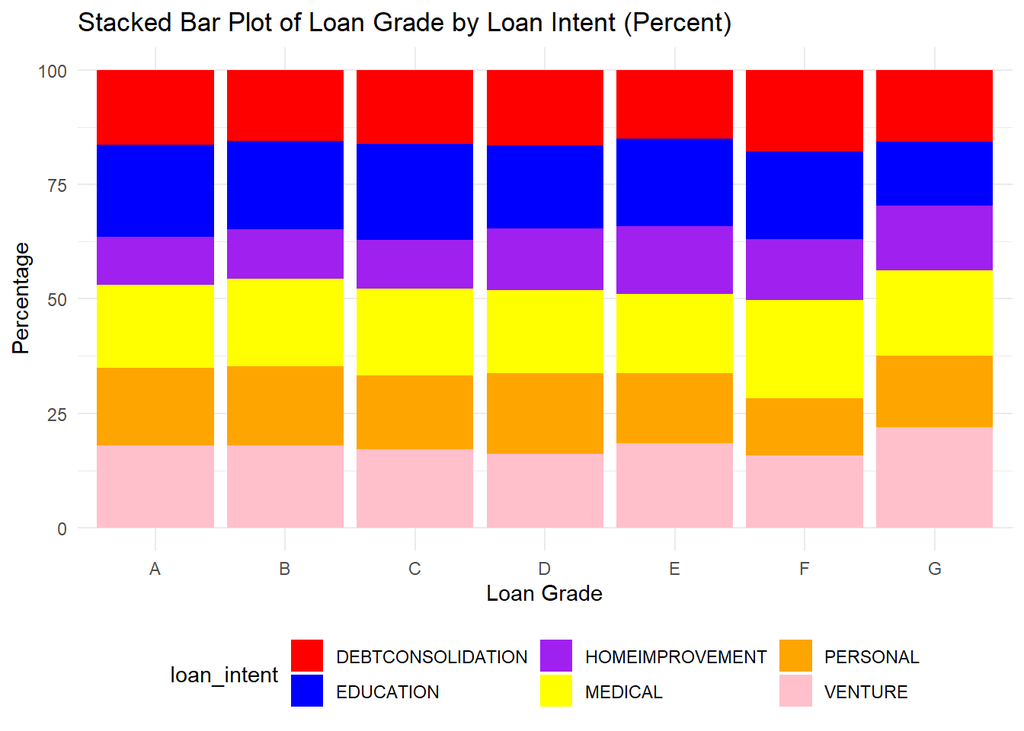

```r
df_percent <- credit_risk_dataset %>%
  group_by(loan_grade, loan_intent) %>%
  summarise(count = n()) %>%
  group_by(loan_grade) %>%
  mutate(percent = count / sum(count) * 100)

# Create the stacked bar plot with percentages
ggplot(df_percent, aes(x = loan_grade, y = percent, fill = loan_intent)) +
  geom_bar(stat = "identity") +
  labs(title = "Stacked Bar Plot of Loan Grade by Loan Intent (Percent)",
       x = "Loan Grade",
       y = "Percentage") +
  scale_fill_manual(values = c("red", "blue", "purple", "yellow", "orange", "pink")) +
  theme_minimal() +
  theme(legend.position = "bottom")
```

From the stacked bar chart and the percentages, we can see thal all intent and loan grades are very similar and there does not seem to be a significant difference. This means this feature should not be selected and focused on in answering the question on if someone will default on their loan (loan_status).

Finally we will explore the relationship between one numerical variable, loan interest rate, with a categorical feature, home ownership. This will be explored using boxplots.

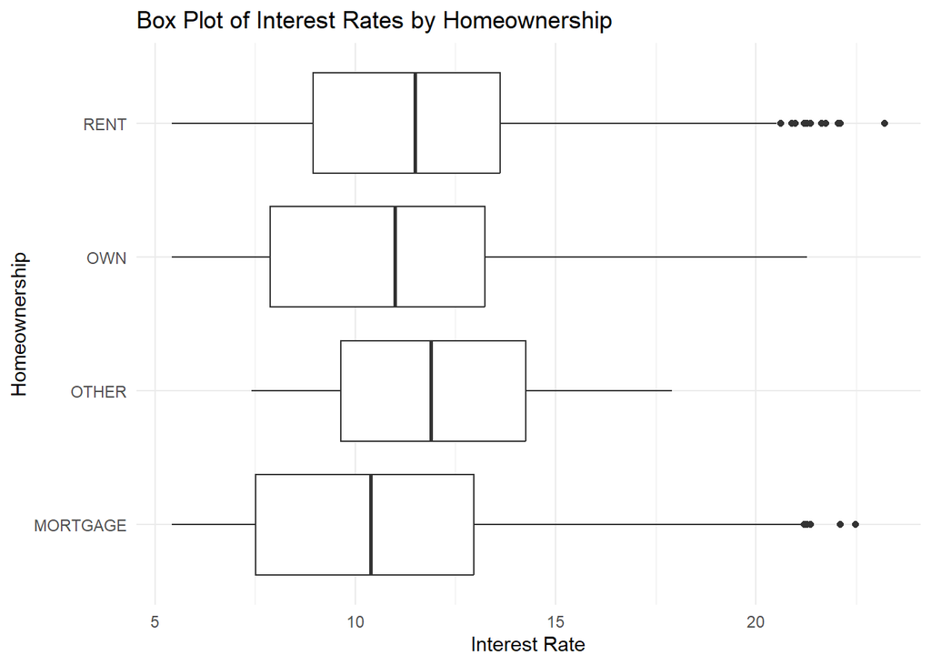

```r
ggplot(credit_risk_dataset, aes(x = loan_int_rate, y = person_home_ownership)) +
  geom_boxplot() +
  labs(title = "Box Plot of Interest Rates by Homeownership",
       x = "Interest Rate",
       y = "Homeownership") +
  theme_minimal()
```

Looking at the different plots, we can see they are all similar except for the “Other” category for Homeownership. This indicates from my perspective to target younger adults who might live at home. These individuals might be using loans with a low income, which can cause higher interest rates. Therefore, homeownership is a potentally important feature we should put into our linear regression model.

## 3. Feauture Engineering

Above we have identified many illogical outliers such as outrageous ages and working experience. Below we will filter out these outliers again using our imputed data

```r
credit_risk <- credit_risk_dataset_imputed %>%
    filter(!is.na(person_emp_length)) %>%
    filter(!is.na(loan_int_rate)) %>%
    filter(person_age < 90) %>%
    filter(person_emp_length < 100)

summary(credit_risk)
```

```
   person_age    person_income     person_home_ownership person_emp_length
 Min.   :20.00   Min.   :   4000   MORTGAGE:13441        Min.   : 0.000
 1st Qu.:23.00   1st Qu.:  38500   OTHER   :  107        1st Qu.: 2.000
 Median :26.00   Median :  55000   OWN     : 2584        Median : 4.000
 Mean   :27.72   Mean   :  65880   RENT    :16441        Mean   : 4.776
 3rd Qu.:30.00   3rd Qu.:  79200                         3rd Qu.: 7.000
 Max.   :84.00   Max.   :2039784                         Max.   :41.000

            loan_intent   loan_grade   loan_amnt     loan_int_rate
 DEBTCONSOLIDATION:5212   A:10776    Min.   :  500   Min.   : 5.42
 EDUCATION        :6451   B:10448    1st Qu.: 5000   1st Qu.: 7.88
 HOMEIMPROVEMENT  :3605   C: 6455    Median : 8000   Median :10.99
 MEDICAL          :6070   D: 3625    Mean   : 9588   Mean   :11.01
 PERSONAL         :5519   E:  964    3rd Qu.:12200   3rd Qu.:13.47
 VENTURE          :5716   F:  241    Max.   :35000   Max.   :23.22
                          G:   64
 loan_status loan_percent_income cb_person_default_on_file
 0:25466     Min.   :0.0000      N:26829
 1: 7107     1st Qu.:0.0900      Y: 5744
             Median :0.1500
             Mean   :0.1702
             3rd Qu.:0.2300
             Max.   :0.8300

 cb_person_cred_hist_length
 Min.   : 2.000
 1st Qu.: 3.000
 Median : 4.000
 Mean   : 5.803
 3rd Qu.: 8.000
 Max.   :30.000
```

```r
# Log Transformation (for positively skewed variables)
credit_risk <- credit_risk %>%
  mutate(person_income_log = log1p(person_income),  # log1p(x) = log(x + 1) to handle zeros
         loan_amnt_log = log1p(loan_amnt))

# Square Root Transformation (moderate skewness)
credit_risk <- credit_risk %>%
  mutate(person_age_sqrt = sqrt(person_age),
         person_emp_length_sqrt = sqrt(person_emp_length),
         cb_person_cred_hist_length_sqrt = sqrt(cb_person_cred_hist_length))

# Inverse Transformation (for extreme right skew)
credit_risk <- credit_risk %>%
  mutate(loan_int_rate_inv = 1 / (loan_int_rate + 1),  # Avoid division by zero
         loan_percent_income_inv = 1 / (loan_percent_income + 1))
```

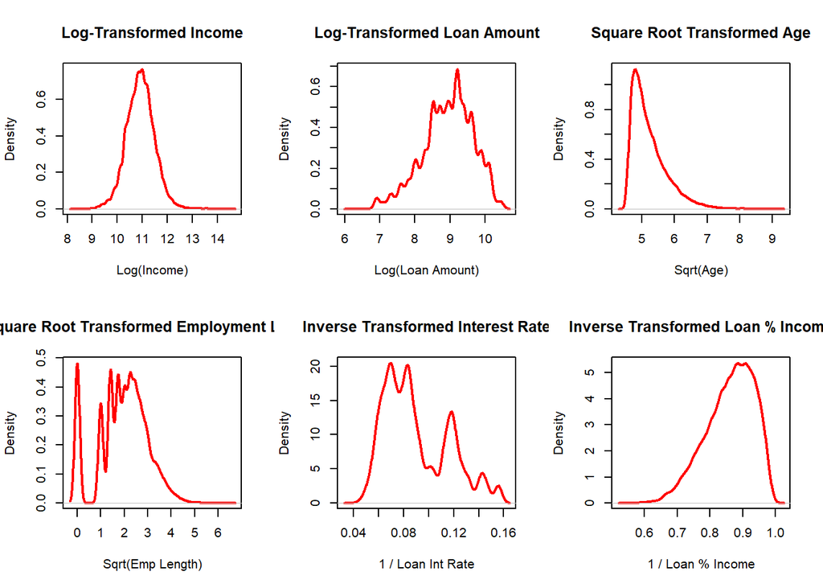

```r
par(mfrow = c(2, 3))  # Arrange plots in a grid


plot(density(credit_risk$person_income_log, na.rm = TRUE),
     main = "Log-Transformed Income", xlab = "Log(Income)", col = "red", lwd = 2)

plot(density(credit_risk$loan_amnt_log, na.rm = TRUE),
     main = "Log-Transformed Loan Amount", xlab = "Log(Loan Amount)", col = "red", lwd = 2)

plot(density(credit_risk$person_age_sqrt, na.rm = TRUE),
     main = "Square Root Transformed Age", xlab = "Sqrt(Age)", col = "red", lwd = 2)

plot(density(credit_risk$person_emp_length_sqrt, na.rm = TRUE),
     main = "Square Root Transformed Employment Length", xlab = "Sqrt(Emp Length)", col = "red", lwd = 2)

plot(density(credit_risk$loan_int_rate_inv, na.rm = TRUE),
     main = "Inverse Transformed Interest Rate", xlab = "1 / Loan Int Rate", col = "red", lwd = 2)

plot(density(credit_risk$loan_percent_income_inv, na.rm = TRUE),
     main = "Inverse Transformed Loan % Income", xlab = "1 / Loan % Income", col = "red", lwd = 2)
```

## 4. Feature Selection and Creation

Above we have identified categorical variables that should be regrouped to simplify our model. Regrouping simplifies our model, which improves our power.

These can be shown being regrouped below:

```r
# 1. Regrouping Credit History (cb_person_cred_hist_length) into categories
filtered_dataset <- credit_risk %>%
  mutate(credit_history_group = case_when(
    cb_person_cred_hist_length <= 5 ~ "0-5 years",
    cb_person_cred_hist_length <= 10 ~ "5-10 years",
    cb_person_cred_hist_length > 10 ~ "11+ years"
  ))

# 2. Regrouping Loan Grade (loan_grade) into groups
filtered_dataset_ <- credit_risk %>%
  mutate(loan_grade_group = case_when(
    loan_grade %in% c("A", "B") ~ "A-B",
    loan_grade %in% c("C", "D") ~ "C-D",
    loan_grade %in% c("E", "F", "G") ~ "E-G"
  ))

# 3. Regrouping Loan Intent (loan_intent) into Necessity vs Want
filtered_dataset_ <- credit_risk%>%
  mutate(loan_intent_group = case_when(
    loan_intent == "MEDICAL" ~ "Necessity",
    loan_intent %in% c("PERSONAL", "VENTURE") ~ "Want",
    loan_intent == "EDUCATION" ~ "Other"  # If you want to handle other categories
  ))

# Check the results
head(filtered_dataset)
```

```
  person_age person_income person_home_ownership person_emp_length loan_intent
1         21          9600                   OWN                 5   EDUCATION
2         25          9600              MORTGAGE                 1     MEDICAL
3         23         65500                  RENT                 4     MEDICAL
4         24         54400                  RENT                 8     MEDICAL
5         21          9900                   OWN                 2     VENTURE
6         26         77100                  RENT                 8   EDUCATION
  loan_grade loan_amnt loan_int_rate loan_status loan_percent_income
1          B      1000         11.14           0                0.10
2          C      5500         12.87           1                0.57
3          C     35000         15.23           1                0.53
4          C     35000         14.27           1                0.55
5          A      2500          7.14           1                0.25
6          B     35000         12.42           1                0.45
  cb_person_default_on_file cb_person_cred_hist_length person_income_log
```

[output cut: 27 more lines]

Now let’s move in discrectizing some of our numerical variables. This is useful for multiple reasons, including improving model interpretability, handling non-linearity, and reducing noisy data. This os grouping continuous data. Some of the variables we are going to discretize are age, income and interest rates.

Below is the code in order to discretize data

```r
credit_risk <- credit_risk %>%
  # Discretize Age
  mutate(person_age= case_when(
    person_age <= 30 ~ "Young",
    person_age > 30 & person_age <= 50 ~ "Middle-Aged",
    person_age > 50 ~ "Older",
    TRUE ~ NA_character_  # Handle unexpected values
  )) %>%

  # Discretize Income
  mutate(person_income = case_when(
    person_income < 25000 ~ "Low Income",
    person_income >= 25000 & person_income <= 75000 ~ "Middle Income",
    person_income > 75000 ~ "High Income",
    TRUE ~ NA_character_
  )) %>%

  # Discretize Loan Interest Rate
  mutate(loan_int_rate = case_when(
    loan_int_rate < 10 ~ "Low Interest",
    loan_int_rate >= 10 & loan_int_rate <= 20 ~ "Medium Interest",
    loan_int_rate > 20 ~ "High Interest",
    TRUE ~ NA_character_
  )) %>%

  # Discretize Loan Percentage of Income
  mutate(loan_percent_income = case_when(
    loan_percent_income < 0.2 ~ "Low Burden",
    loan_percent_income >= 0.2 & loan_percent_income <= 0.5 ~ "Medium Burden",
    loan_percent_income > 0.5 ~ "High Burden",
    TRUE ~ NA_character_
  ))

# Convert new columns to factors

# Check the first few rows
head(credit_risk)
```

```
  person_age person_income person_home_ownership person_emp_length loan_intent
1      Young    Low Income                   OWN                 5   EDUCATION
2      Young    Low Income              MORTGAGE                 1     MEDICAL
3      Young Middle Income                  RENT                 4     MEDICAL
4      Young Middle Income                  RENT                 8     MEDICAL
5      Young    Low Income                   OWN                 2     VENTURE
6      Young   High Income                  RENT                 8   EDUCATION
  loan_grade loan_amnt   loan_int_rate loan_status loan_percent_income
1          B      1000 Medium Interest           0          Low Burden
2          C      5500 Medium Interest           1         High Burden
3          C     35000 Medium Interest           1         High Burden
4          C     35000 Medium Interest           1         High Burden
5          A      2500    Low Interest           1       Medium Burden
6          B     35000 Medium Interest           1       Medium Burden
  cb_person_default_on_file cb_person_cred_hist_length person_income_log
```

[output cut: 20 more lines]

## 5. Linear Regression

We can use a linear model for finding association features to the loan amounts.The feature, loan_amnt_log, which tells tells what how much a client’s loan is worth.

### Create Candidate Models

The full/initial model containing all of the predictor variables will be made first, with ‘loan_amnt_log’ as the response. The features that were all transformed above will be used.

```r
# Fit the linear regression model
linear_model <- lm(loan_amnt_log ~ person_age_sqrt + person_income_log + person_home_ownership +
                   person_emp_length_sqrt + loan_intent + loan_grade + loan_int_rate +
                   loan_percent_income_inv + cb_person_default_on_file + cb_person_cred_hist_length_sqrt,
                   data = credit_risk)

# Print summary to view the coefficients and significance tests
summary(linear_model)
```

```
Call:
lm(formula = loan_amnt_log ~ person_age_sqrt + person_income_log +
    person_home_ownership + person_emp_length_sqrt + loan_intent +
    loan_grade + loan_int_rate + loan_percent_income_inv + cb_person_default_on_file +
    cb_person_cred_hist_length_sqrt, data = credit_risk)

Residuals:
    Min      1Q  Median      3Q     Max
-3.7845 -0.0677  0.0793  0.1380  0.3714

Coefficients:
                                  Estimate Std. Error  t value Pr(>|t|)
(Intercept)                      6.2225062  0.0459694  135.362  < 2e-16 ***
person_age_sqrt                 -0.0016857  0.0044803   -0.376 0.706735
person_income_log                0.9668156  0.0025287  382.343  < 2e-16 ***
person_home_ownershipOTHER      -0.0234537  0.0215740   -1.087 0.276989
person_home_ownershipOWN        -0.0243900  0.0049002   -4.977 6.48e-07 ***
person_home_ownershipRENT       -0.0059063  0.0028097   -2.102 0.035551 *
person_emp_length_sqrt          -0.0012918  0.0012494   -1.034 0.301168
loan_intentEDUCATION             0.0077109  0.0041530    1.857 0.063363 .
loan_intentHOMEIMPROVEMENT       0.0087400  0.0048404    1.806 0.070984 .
loan_intentMEDICAL               0.0198291  0.0042056    4.715 2.43e-06 ***
loan_intentPERSONAL              0.0115074  0.0043002    2.676 0.007454 **
loan_intentVENTURE               0.0070604  0.0042902    1.646 0.099835 .
loan_gradeB                     -0.0193637  0.0057840   -3.348 0.000815 ***
loan_gradeC                     -0.0214948  0.0071502   -3.006 0.002648 **
loan_gradeD                      0.0002782  0.0075810    0.037 0.970723
loan_gradeE                     -0.0012237  0.0097338   -0.126 0.899955
loan_gradeF                     -0.0074567  0.0162297   -0.459 0.645915
loan_gradeG                     -0.0565733  0.0370228   -1.528 0.126506
loan_int_rateLow Interest       -0.0754293  0.0339581   -2.221 0.026341 *
loan_int_rateMedium Interest    -0.0573259  0.0334510   -1.714 0.086588 .
loan_percent_income_inv         -8.9987891  0.0184391 -488.026  < 2e-16 ***
cb_person_default_on_fileY      -0.0037185  0.0041698   -0.892 0.372516
cb_person_cred_hist_length_sqrt -0.0050326  0.0032082   -1.569 0.116735
---
Signif. codes:  0 '***' 0.001 '**' 0.01 '*' 0.05 '.' 0.1 ' ' 1

Residual standard error: 0.222 on 32550 degrees of freedom
Multiple R-squared:  0.9028,    Adjusted R-squared:  0.9027
F-statistic: 1.373e+04 on 22 and 32550 DF,  p-value: < 2.2e-16
```

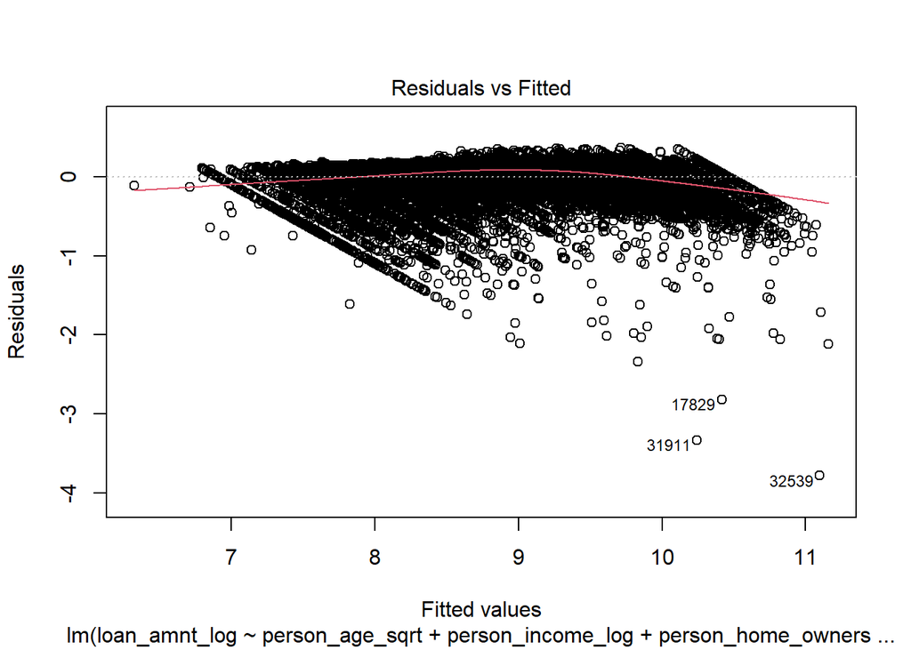

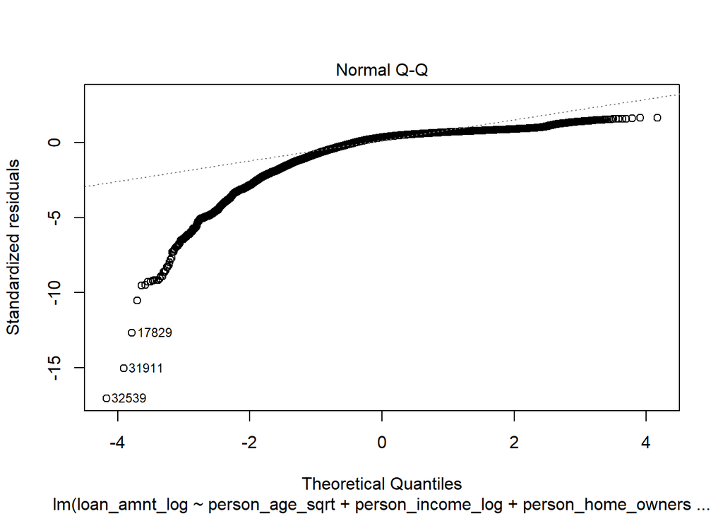

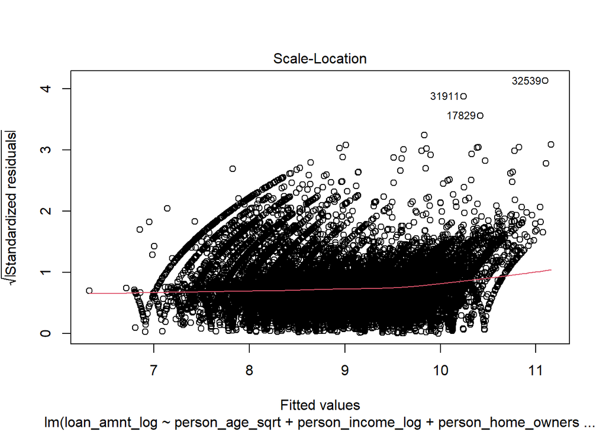

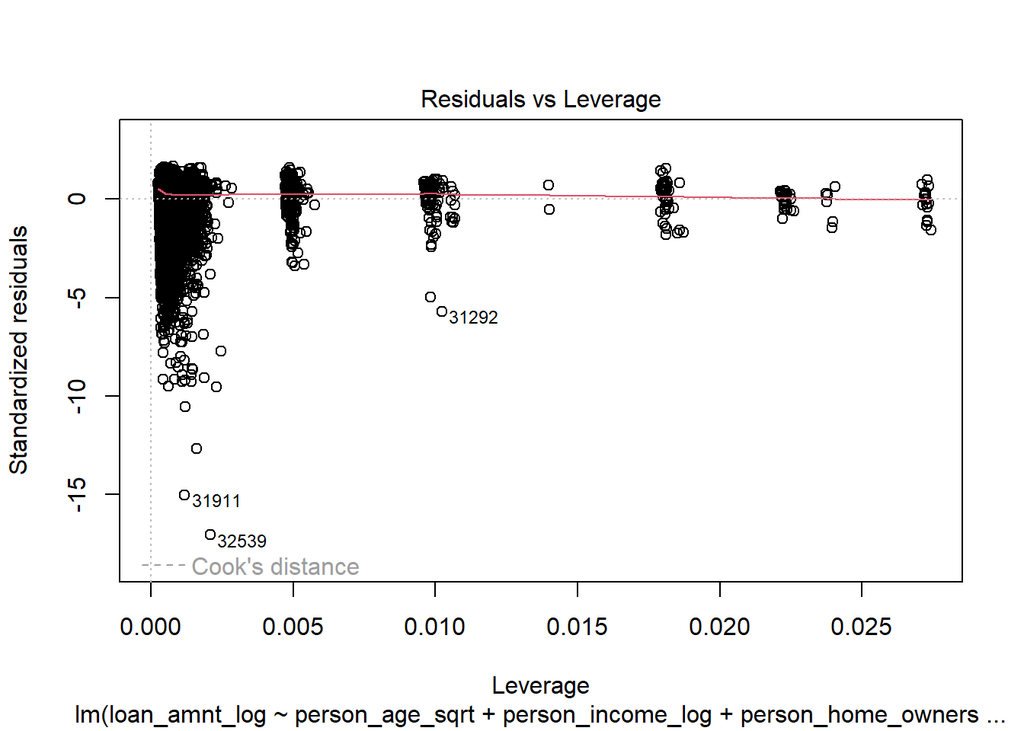

```r
# Diagnostic plots to assess the assumptions of linear regression
plot(linear_model)
```

```r
# Extract and display the coefficients and significance tests
coefficient_table <- summary(linear_model)$coef
library(knitr)
kable(coefficient_table, caption = "Significance tests of linear regression model")
```

Significance tests of linear regression model

|  | Estimate | Std. Error | t value | Pr(>\|t\|) |
| --- | --- | --- | --- | --- |
| (Intercept) | 6.2225062 | 0.0459694 | 135.3618705 | 0.0000000 |
| person_age_sqrt | -0.0016857 | 0.0044803 | -0.3762486 | 0.7067345 |
| person_income_log | 0.9668156 | 0.0025287 | 382.3432165 | 0.0000000 |
| person_home_ownershipOTHER | -0.0234537 | 0.0215740 | -1.0871256 | 0.2769893 |
| person_home_ownershipOWN | -0.0243900 | 0.0049002 | -4.9773774 | 0.0000006 |
| person_home_ownershipRENT | -0.0059063 | 0.0028097 | -2.1021131 | 0.0355510 |
| person_emp_length_sqrt | -0.0012918 | 0.0012494 | -1.0339490 | 0.3011677 |
| loan_intentEDUCATION | 0.0077109 | 0.0041530 | 1.8567025 | 0.0633625 |
| loan_intentHOMEIMPROVEMENT | 0.0087400 | 0.0048404 | 1.8056382 | 0.0709841 |
| loan_intentMEDICAL | 0.0198291 | 0.0042056 | 4.7149262 | 0.0000024 |
| loan_intentPERSONAL | 0.0115074 | 0.0043002 | 2.6760022 | 0.0074543 |
| loan_intentVENTURE | 0.0070604 | 0.0042902 | 1.6457005 | 0.0998351 |
| loan_gradeB | -0.0193637 | 0.0057840 | -3.3478241 | 0.0008154 |
| loan_gradeC | -0.0214948 | 0.0071502 | -3.0061639 | 0.0026477 |
| loan_gradeD | 0.0002782 | 0.0075810 | 0.0367017 | 0.9707231 |
| loan_gradeE | -0.0012237 | 0.0097338 | -0.1257189 | 0.8999552 |
| loan_gradeF | -0.0074567 | 0.0162297 | -0.4594494 | 0.6459146 |
| loan_gradeG | -0.0565733 | 0.0370228 | -1.5280656 | 0.1265060 |
| loan_int_rateLow Interest | -0.0754293 | 0.0339581 | -2.2212448 | 0.0263412 |
| loan_int_rateMedium Interest | -0.0573259 | 0.0334510 | -1.7137281 | 0.0865882 |
| loan_percent_income_inv | -8.9987891 | 0.0184391 | -488.0264170 | 0.0000000 |
| cb_person_default_on_fileY | -0.0037185 | 0.0041698 | -0.8917821 | 0.3725163 |
| cb_person_cred_hist_length_sqrt | -0.0050326 | 0.0032082 | -1.5686694 | 0.1167347 |

```r
# Adjusted R-squared and F-statistic for model evaluation
cat("Adjusted R-squared: ", summary(linear_model)$adj.r.squared, "\n")
```

```
Adjusted R-squared:  0.9026856
```

```r
cat("F-statistic: ", summary(linear_model)$fstatistic[1], "\n")
```

```
F-statistic:  13734.5
```

```r
cat("p-value: ", summary(linear_model)$fstatistic[4], "\n")
```

```
p-value:  NA
```

We can see that there are some insignificant predictor variables, and they should be dropped from the model. Using the step() function, we will now find the final model. The final best model will be a model that is between the full and reduced models.

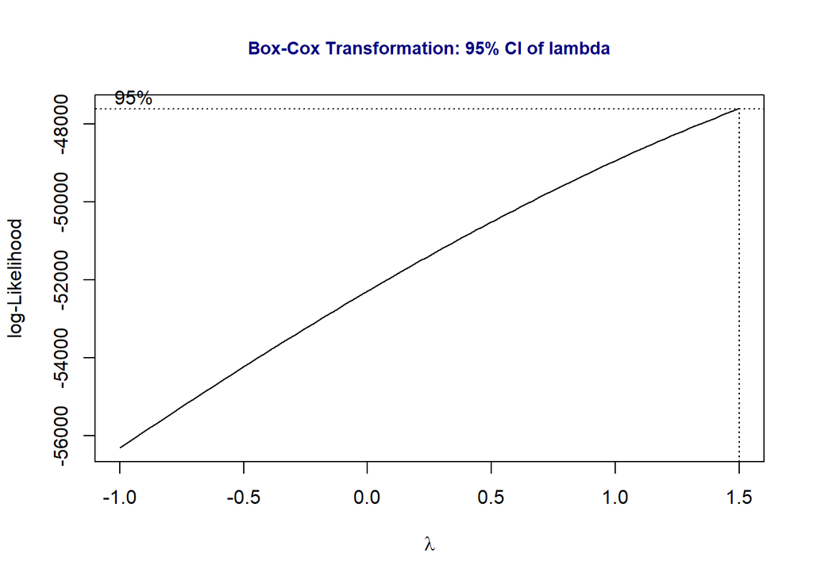

```r
library(MASS)

# Box-Cox Transformation for the 'loan_int_rate' variable to find optimal lambda
boxcox(loan_amnt_log ~ person_age_sqrt + person_income_log + person_home_ownership +
                   person_emp_length_sqrt + loan_intent + loan_grade + loan_int_rate +
                   loan_percent_income_inv + cb_person_default_on_file + cb_person_cred_hist_length_sqrt,
                   data = credit_risk,
       lambda = seq(-1, 1.5, length = 10),
       xlab = expression(paste(lambda)))

title(main = "Box-Cox Transformation: 95% CI of lambda",
      col.main = "navy", cex.main = 0.9)
```

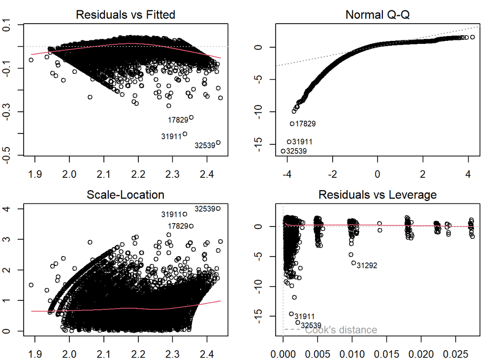

```r
# Log transformation of the target variable ('loan_int_rate')
transform.model = lm(log(loan_amnt_log) ~ person_age_sqrt + person_income_log + person_home_ownership +
                   person_emp_length_sqrt + loan_intent + loan_grade + loan_int_rate +
                   loan_percent_income_inv + cb_person_default_on_file + cb_person_cred_hist_length_sqrt,
                   data = credit_risk)

# Diagnostic plots for the log-transformed model
par(mfrow = c(2, 2), mar = c(2, 2, 2, 2))
plot(transform.model)
```

```r
# Summarize the coefficients of the transformed model
kable(summary(transform.model)$coef, caption = "Summarized statistics of the regression coefficients of the log-transformed model")
```

Summarized statistics of the regression coefficients of the log-transformed model

|  | Estimate | Std. Error | t value | Pr(>\|t\|) |
| --- | --- | --- | --- | --- |
| (Intercept) | 1.8843487 | 0.0057151 | 329.7146947 | 0.0000000 |
| person_age_sqrt | -0.0002992 | 0.0005570 | -0.5372096 | 0.5911265 |
| person_income_log | 0.1097403 | 0.0003144 | 349.0774716 | 0.0000000 |
| person_home_ownershipOTHER | -0.0023468 | 0.0026822 | -0.8749545 | 0.3816051 |
| person_home_ownershipOWN | -0.0028871 | 0.0006092 | -4.7390634 | 0.0000022 |
| person_home_ownershipRENT | -0.0004399 | 0.0003493 | -1.2594019 | 0.2078942 |
| person_emp_length_sqrt | -0.0001567 | 0.0001553 | -1.0090240 | 0.3129706 |
| loan_intentEDUCATION | 0.0008806 | 0.0005163 | 1.7055596 | 0.0880997 |
| loan_intentHOMEIMPROVEMENT | 0.0010287 | 0.0006018 | 1.7093733 | 0.0873914 |
| loan_intentMEDICAL | 0.0022627 | 0.0005229 | 4.3276670 | 0.0000151 |
| loan_intentPERSONAL | 0.0014940 | 0.0005346 | 2.7945854 | 0.0051997 |
| loan_intentVENTURE | 0.0008784 | 0.0005334 | 1.6469562 | 0.0995767 |
| loan_gradeB | -0.0030046 | 0.0007191 | -4.1783353 | 0.0000294 |
| loan_gradeC | -0.0029997 | 0.0008889 | -3.3744103 | 0.0007406 |
| loan_gradeD | -0.0009500 | 0.0009425 | -1.0079392 | 0.3134911 |
| loan_gradeE | -0.0018520 | 0.0012101 | -1.5303986 | 0.1259278 |
| loan_gradeF | -0.0035663 | 0.0020177 | -1.7675042 | 0.0771532 |
| loan_gradeG | -0.0106308 | 0.0046028 | -2.3096323 | 0.0209147 |
| loan_int_rateLow Interest | -0.0093194 | 0.0042218 | -2.2074449 | 0.0272899 |
| loan_int_rateMedium Interest | -0.0073959 | 0.0041588 | -1.7783972 | 0.0753480 |
| loan_percent_income_inv | -1.0258120 | 0.0022924 | -447.4793956 | 0.0000000 |
| cb_person_default_on_fileY | -0.0005601 | 0.0005184 | -1.0804783 | 0.2799372 |
| cb_person_cred_hist_length_sqrt | -0.0005377 | 0.0003989 | -1.3481939 | 0.1776054 |

```r
# Stepwise regression to select the best model (backward elimination)
final.model = step(transform.model, direction = "backward", trace = 0)

# Summarize the coefficients of the final model after stepwise selection
kable(summary(final.model)$coef, caption = "Summary statistics of the regression coefficients of the final model")
```

Summary statistics of the regression coefficients of the final model

|  | Estimate | Std. Error | t value | Pr(>\|t\|) |
| --- | --- | --- | --- | --- |
| (Intercept) | 1.8834275 | 0.0053804 | 350.0505910 | 0.0000000 |
| person_income_log | 0.1096856 | 0.0003108 | 352.9549535 | 0.0000000 |
| person_home_ownershipOTHER | -0.0022767 | 0.0026805 | -0.8493342 | 0.3957016 |
| person_home_ownershipOWN | -0.0028730 | 0.0006090 | -4.7176241 | 0.0000024 |
| person_home_ownershipRENT | -0.0003761 | 0.0003434 | -1.0951780 | 0.2734468 |
| loan_intentEDUCATION | 0.0009000 | 0.0005160 | 1.7441930 | 0.0811349 |
| loan_intentHOMEIMPROVEMENT | 0.0010192 | 0.0006014 | 1.6947877 | 0.0901253 |
| loan_intentMEDICAL | 0.0022557 | 0.0005228 | 4.3146781 | 0.0000160 |
| loan_intentPERSONAL | 0.0014905 | 0.0005346 | 2.7880986 | 0.0053049 |
| loan_intentVENTURE | 0.0008781 | 0.0005334 | 1.6463062 | 0.0997104 |
| loan_gradeB | -0.0030015 | 0.0007191 | -4.1742880 | 0.0000300 |
| loan_gradeC | -0.0032699 | 0.0008496 | -3.8485277 | 0.0001191 |
| loan_gradeD | -0.0012394 | 0.0009035 | -1.3717085 | 0.1701637 |
| loan_gradeE | -0.0021025 | 0.0011836 | -1.7763320 | 0.0756875 |
| loan_gradeF | -0.0037909 | 0.0020027 | -1.8929474 | 0.0583737 |
| loan_gradeG | -0.0109329 | 0.0045932 | -2.3802450 | 0.0173069 |
| loan_int_rateLow Interest | -0.0092838 | 0.0042216 | -2.1991097 | 0.0278771 |
| loan_int_rateMedium Interest | -0.0073582 | 0.0041586 | -1.7694224 | 0.0768328 |
| loan_percent_income_inv | -1.0257770 | 0.0022907 | -447.7989340 | 0.0000000 |
| cb_person_cred_hist_length_sqrt | -0.0007371 | 0.0002035 | -3.6220025 | 0.0002928 |